# p8105_HW1_tc2899

Thomas Carpino, tc2899

Here I am loading knitr!

**Problem 1:**

Create a data frame comprised of:

- A random sample of size 10 from a uniform[0, 5] distribution –> done
- A logical vector indicating whether elements of the sample are greater than 2 –> done
- A (length-10) character vector –> done
- A (length-10) factor vector –> done

Here I am loading tidyverse.

```r
library(tidyverse)
## set seed to ensure reproducibility

set.seed(98)

## creating my data frame

problem1 = tibble(
  vec_numeric = runif(10, min = 0, max = 5),
  vec_logical = c(vec_numeric > 2),
  vec_char = c("I", "think", "data", "science", "is", "a", "really", "really", "cool", "class"),
  vec_factor = factor(c("big", "small", "big", "small", "small","big", "small", "big", "small", "small"))
)

## here I am taking the mean of each of the different variables.
mean(problem1$vec_numeric)
```

```
## [1] 1.774789
```

```r
mean(problem1$vec_logical)
```

```
## [1] 0.4
```

```r
mean(problem1$vec_char)
```

```
## [1] NA
```

```r
mean(problem1$vec_factor)
```

```
## [1] NA
```

When taking the mean of each variable of the dataframe, vec_numeric and vec_logical both work, whereas vec_char and vec_factor do not work. This is because the mathematical average can be found for the first two variables, where vec_numeric ranges from 0 to 5, and vec_logic ranges from 0 to 1. The other two variables cannot be computed using letters as is - NAs are produced as the result.

```r
as.numeric(problem1$vec_logical)
```

```
##  [1] 1 0 0 1 0 0 0 1 1 0
```

```r
as.numeric(problem1$vec_char)
```

```
##  [1] NA NA NA NA NA NA NA NA NA NA
```

```r
as.numeric(problem1$vec_factor)
```

```
##  [1] 1 2 1 2 2 1 2 1 2 2
```

```r
## Above, I am trying to coerce the different variables (logical, character, and factor) to become numeric variables.
```

When converting the logical, character, and factor variables ot numeric variables, only logical and factor function properly. The character variable did not convert to numeric - NAs are produced ‘by coercion’.

```r
as.numeric(as.factor(problem1$vec_char))
```

```
##  [1] 5 9 4 8 6 1 7 7 3 2
```

```r
as.numeric(as.character(problem1$vec_factor))
```

```
##  [1] NA NA NA NA NA NA NA NA NA NA
```

```r
## Above, I am attempting to coerce (char -> factor -> numeric) and (factor -> char -> numeric)
```

**Problem 2:**

```r
## Here, I am loading tidyverse once again:

library(tidyverse)

## Setting the seed:

set.seed(98)

## Creating the dataframe for problem 2:

problem2 = tibble(
  x = rnorm(1000),
  y = rnorm(1000),
  logical = c(x + y > 0),
  numeric = as.numeric(logical),
  factor = as.factor(logical)
  )
```

**Description of the dataframe:** The size of the dataset is 1000, 5. The mean of x is -0.0168511 and the median of x is -0.0039669. The proportion of cases for which the logical vector is TRUE is 0.495.

**Scatterplots / Visualizations**

Here, I am creating a scatterplot of y vs x (as requested in the homework), and am using the logical vector to determine the color scale. When the logical statement is true (X+Y>0), then the point will be blue (TRUE) whereas when the logical statement is FALSE, the points will appear red.

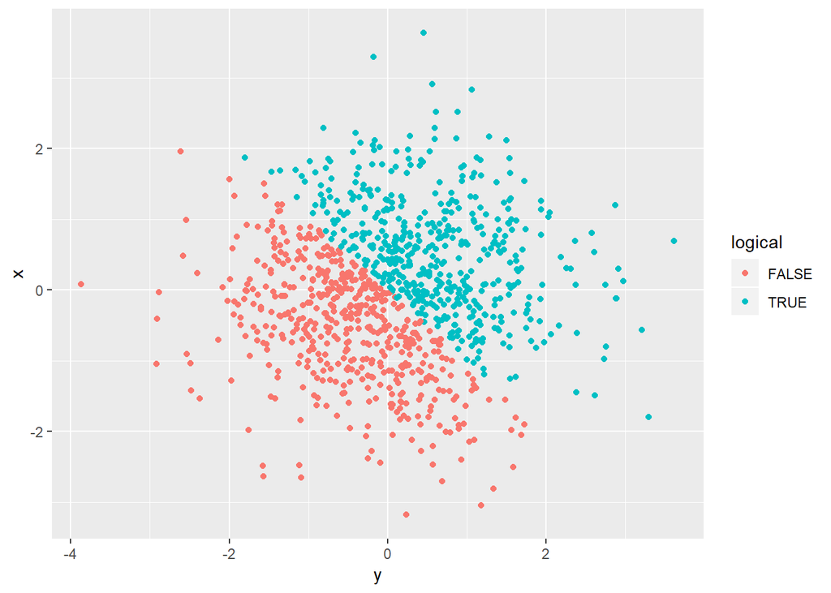

```r
ggplot(problem2, aes(x = y, y = x, color = logical)) + geom_point()
```

```r
ggsave("problem2.pdf")
```

Here is a second scatterplot of y vs x, where the color points are being determined by the numeric vector. Since the numeric vector is either 0 or 1, the points will either appear light blue (1.0) or dark blue/ black (0.0).

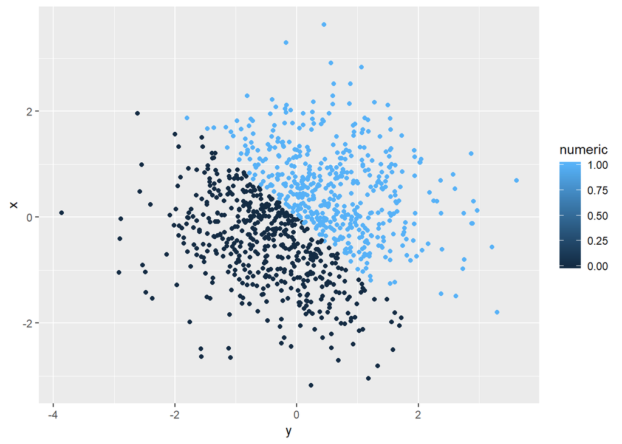

```r
ggplot(problem2, aes(x = y, y = x, color = numeric)) + geom_point()
```

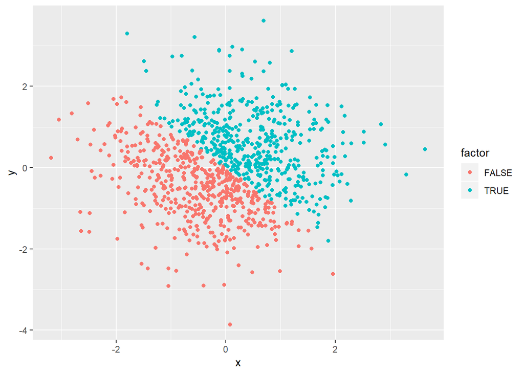

```r
ggplot(problem2, aes(x = x, y = y, color = factor)) + geom_point()
```